# What Is an Algorithm?

BIOL 5/6800 — Intro to Comp Bio

## Today’s objectives

- What is an algorithm?
  - Basic types
- How do we compare/choose algorithms?
  - Time/space complexity: “Big O” notation
- Time-memory trade-off
- Exercise 5 (next time)

# Why computational biology? (Review from last time)

**Example 1 — Reading a genome you never see**

You sequence a bacterial isolate and get back 4 million short reads, each ~150 bp, in random order, with errors.

**The question:** what is the genome?

**The problem:** this is a jigsaw puzzle with millions of pieces, no picture on the box, some pieces duplicated, and some pieces wrong.

Nobody solves this by hand. An *assembly algorithm* does — by building a graph of overlapping *k*-mers and finding a path through it.

**Example 2 — Pathogen surveillance in real time**

During SARS-CoV-2, sequences were deposited daily and phylogenies were rebuilt continuously to track which lineages were spreading where

That pipeline is a stack of algorithms:

- align millions of genomes to a reference
- infer a tree relating them
- map the tree onto geography and time

If the tree takes six weeks to compute, the answer is useless. **Speed is not a convenience here — it is the whole point.**

## Another example

How many possible trees relate $n$ species?

$$(2n - 3)!!$$

| Taxa | Possible trees |
| --- | --- |
| 5 | 105 |
| 10 | ~$3.4 \times 10^{7}$ |
| 20 | ~$8.2 \times 10^{21}$ |
| 52 | ~$2.8 \times 10^{80}$ |

There are roughly $10^{80}$ atoms in the observable universe.

## The takeaway

> A biological question becomes a computational question when we have to specify **exactly how** to get from data to answer.

# Algorithms

## What is an algorithm?

A finite, unambiguous sequence of steps that transforms an **input** into an **output**.

A recipe is an algorithm. So is long division. So is:

```python
def gc_content(seq):
    gc = 0
    for base in seq:
        if base in "GCgc":
            gc += 1
    return gc / len(seq)
```

**An algorithm is the idea; code is one expression of it**

## Two questions about any algorithm

### Is it correct?

Does it give the right answer for **every** valid input, not just the one you tested?

### Is it feasible?

Will it finish before your grant does? Will it fit in memory?

For most of biology, correctness is necessary but *feasibility decides what you can actually ask*

## Families of algorithmic strategies

Rather than memorize algorithms, learn to recognize **strategies**:

1. **Exhaustive / brute force**: try everything
2. **Divide and conquer**: split, solve, recombine
3. **Dynamic programming**: solve subproblems once and reuse
4. **Greedy**: take the locally best step, never look back
5. **Heuristic**: trade guarantees for speed
6. **Stochastic**: use randomness deliberately

*These are not mutually exclusive; real tools mix them*

## 1. Exhaustive search

**Idea**: enumerate every candidate solution, score each, keep the best

**Pros**

- Guaranteed optimal
- Easy to reason about
- Great for small problems

**Cons**

- Cost (time and/or memory) explodes with input size
- Usually impossible in practice

*Biology*: finding the optimal tree for 7 taxa (10,395 trees — fine). For 30 taxa — not fine, ever.

## 2. Divide and conquer

**Idea**: break the problem into smaller versions of itself, solve those, combine the results.

```python
def binary_search(sorted_values, target):
    lo = 0
    hi = len(sorted_values) - 1
    while lo <= hi:
        mid = (lo + hi) // 2
        if sorted_values[mid] == target:
            return mid
        elif sorted_values[mid] < target:
            lo = mid + 1
        else:
            hi = mid - 1
    return None
```

Each step throws away half the remaining data; searching 1 billion sorted values takes ~30 comparisons

## 3. Dynamic programming

**Idea**: the problem has overlapping subproblems. Solve each one *once*, store the answer, look it up later.

A canonical example in biology is the Needleman–Wunsch algorithm for aligning sequences

## Needleman-Wunsch alignment<sup>1</sup>

$$F(i,j) = \max
\begin{cases}
F(i-1,\,j-1) + s(A_i, B_j) & \text{(match/mismatch)}\\
F(i-1,\,j) + g & \text{(gap in }B)\\
F(i,\,j-1) + g & \text{(gap in }A)
\end{cases}$$

Every cell is computed from cells we already filled in; fill a table, then trace back.

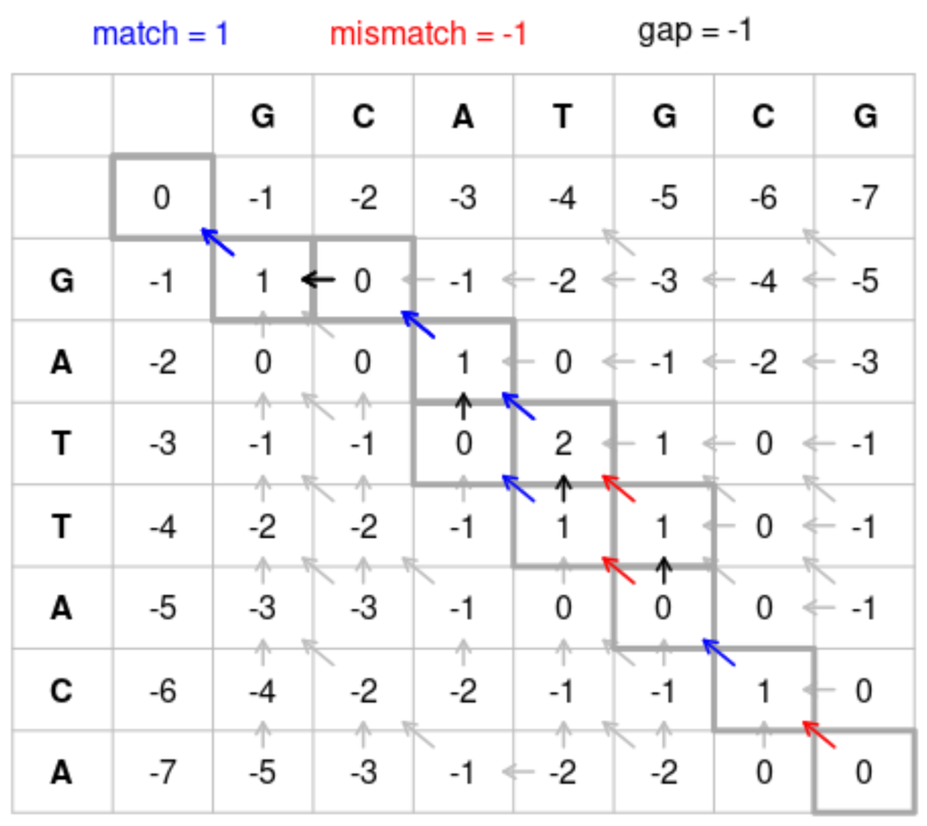

**Guaranteed optimal** and *way* faster than enumerating alignments.

[^1]: Needleman and Wunsch (1970)

## Dynamic programming: why it wins

Example: Calculating Fibonacci numbers ($F_{n}$)

| $n$ | 0 | 1 | 2 | 3 | 4 | 5 | 6 | 7 | 8 | $\ldots$ |
| --- | --- | --- | --- | --- | --- | --- | --- | --- | --- | --- |
| $F_{n}$ | 0 | 1 | 1 | 2 | 3 | 5 | 8 | 13 | 21 | $\ldots$ |

$F_{0} = 0, F_{1} = 1, F_{n} = F_{n-1} + F_{n-2}$

Naive recursive algo recomputes the same values over and over:

```python
def fib_slow(n):
    if n < 2:
        return n
    return fib_slow(n - 1) + fib_slow(n - 2)
```

What if we store all previous Fibonacci numbers?

```python
def fib_fast(n):
    if n < 2:
        return n
    fib_nums = [0] * (n + 1) # Create list of n+1 zeros
    fib_nums[1] = 1
    for i in range(2, n + 1):
        fib_nums[i] = fib_nums[i - 1] + fib_nums[i - 2]
    return fib_nums[n]
```

`fib_slow(40)` takes about a minute; `fib_fast(40)` is instant

Same answer; we just stopped throwing work away

## 4. Greedy algorithms

**Idea**: at each step, take whatever looks best *right now*. Commit. Move on.

**Pros**

- Fast and simple
- Often very good in practice

**Cons**

- No guarantee of the global optimum
- One early bad call propagates

## 4. Greedy algorithms

*Biology example*: UPGMA and neighbor-joining methods for estimating trees

- Both methods repeatedly join the closest pair of clusters and never revisit that decision.

*Analogy*: Hiking to the highest peak by always walking uphill. You will reach *a* summit. Not necessarily the tallest one.

## 5. Heuristics

**Idea**: deliberately give up the guarantee of optimality in exchange for an answer you can actually get (greedy is one type)

*Biology example*: Searching databases for similar sequences with BLAST<sup>1</sup>

- Smith–Waterman algorithm<sup>2</sup> is optimal but far too slow to scan all of GenBank
- BLAST first finds short exact seed matches, then only extends around those

BLAST can miss things, but it is used billions of times a year

“Approximate answer today” beats “exact answer in nine years.”

[^2]: Altschul et al. (1990)
[^3]: Smith and Waterman (1981)

## 6. Stochastic / randomized

**Idea**: use randomness as part of the procedure.

- **Bootstrapping**: resample data to assess variance
- **MCMC**: random walk through model space, guided by the likelihood
- **Randomized starts**: restart a heuristic search from many points; keep the best

Slightly different answers from each run; this is a feature

## Checkpoint

Which strategy would you reach for?

- Find the optimal alignment of two 500-bp sequences
- Find homologs of one protein across all of UniProt (a huge database)
- Find the best phylogenetic tree for 5 species
- Find the best phylogenetic tree for 500 species

# How do we compare algorithms?

## The problem with “it took 12 seconds”

- On which machine?
- With which input?
- In Python or C?
- How many other things were running?

We want something that describes the **algorithm**, not the afternoon

## Big O notation

**Idea**: count how the number of operations grows as the input ($n$) grows, and ignore everything else.

Specifically, we throw away:

- constant factors — $3n$ and $n$ are both $O(n)$
- lower-order terms — $n^2 + 500n + 900$ is $O(n^2)$

We keep only the term that dominates as $n$ gets large.

## Reading big O from code

```python
def count_bases(sequence):
    counts = {}
    for base in sequence:  # O(n) — one pass over n bases
        counts[base] = counts.get(base, 0) + 1
    return counts
```

$O(n)$: Loop over $n$ bases

```python
def pairwise_distances(sequences):
    d = {}
    for i, seq_a in enumerate(sequences):  # O(n^2) — every pair of n sequences
        for j, seq_b in enumerate(sequences):
            if i < j:
                d[(i, j)] = hamming(seq_a, seq_b)
    return d
```

$O(n^2)$: Nested `for` loops for all pairs of $n$ sequences

Rough rule of thumb: **each nested loop over the input multiplies by another factor of $n$.**

## Common complexity classes

| Notation | Name | Example |
| --- | --- | --- |
| $O(1)$ | constant | dict lookup |
| $O(\log n)$ | logarithmic | binary search |
| $O(n)$ | linear | scanning a sequence |
| $O(n \log n)$ | linearithmic | sorting |
| $O(n^2)$ | quadratic | all pairwise comparisons |
| $O(n^3)$ | cubic | some matrix operations |
| $O(2^n)$ | exponential | all subsets |
| $O(n!)$ | factorial | all orderings |

## Why the complexity class matters

Assume ~10 million simple Python operations per second:

| $n$ | $O(n)$ | $O(n \log n)$ | $O(n^2)$ | $O(n^3)$ |
| --- | --- | --- | --- | --- |
| 10 | 1 µs | 3 µs | 10 µs | 100 µs |
| 100 | 10 µs | 66 µs | 1 ms | 100 ms |
| 1,000 | 100 µs | 1 ms | 100 ms | 1.7 min |
| 1,000,000 | 100 ms | 2 s | **1.2 days** | **3,000 yr** |

A better algorithm can scale to lots of data

## Exponential is a different universe

| $n$ | $O(2^n)$ | $O(n!)$ |
| --- | --- | --- |
| 10 | 100 µs | 0.4 s |
| 20 | 100 ms | 7,700 yr |
| 30 | 1.8 min | $8 \times 10^{17}$ yr |
| 50 | 3.6 yr | — |

**Example**: the exhaustive tree search from earlier

It is not a hardware problem, and buying a cluster does not fix it

[interactive chart not shown]

Figure 1: Comparing complexity classes

## Space complexity

The same notation describes **memory**.

- Storing a sequence of length $n$: $O(n)$
- Storing all pairwise distances among $n$ sequences: $O(n^2)$
- The Needleman–Wunsch table for two length-$n$ sequences: $O(n^2)$

Two 100,000-bp sequences:

- A table with $10^{10}$ cells
- At 4 bytes per cell that is ~40 GB.

# The trade-off

## Time and memory pull against each other

### Spend memory, save time

- Precompute and store results so you never recompute them

### Spend time, save memory

- Recompute on-demand and store as little as possible

Almost every real bioinformatics tool sits somewhere on this spectrum, and the position is a **design choice**.

## Trade-off in Python: lists vs sets

```python
gene_ids_list = [...]         # 1,000,000 IDs
gene_ids_set  = set(gene_ids_list)

"BRCA1" in gene_ids_list      # O(n) — scans until found
"BRCA1" in gene_ids_set       # O(1) — hashes and jumps
```

The set is dramatically faster to search — and uses noticeably more memory, because it stores a hash table.

If you do one lookup, use the list

If you do a million lookups, building the set pays for itself

## Trade-off examples

1. **BLAST** builds a *k*-mer index of the database in memory so it never has to scan the whole thing
   - Memory buys speed
2. **Hirschberg’s algorithm**<sup>1</sup> aligns sequences with $O(n)$ memory instead of $O(n^2)$, at roughly twice the runtime
   - Time buys memory
[^4]: Hirschberg (1975)

## Choosing an algorithm

1. How big is $n$, and how big will it be next year?
2. Do I need the guaranteed optimum, or a good answer?
3. Am I running this once, or a million times?
4. What resource am I actually short of: hours or RAM?

There is no “best” algorithm. There is a best algorithm *for your problem, at your scale, under your constraints.*

## Summary

- Biology’s data outgrew our ability to inspect it
  - algorithms are how we cope
- A handful of **strategies** (exhaustive, divide and conquer, DP, greedy, heuristic, stochastic) explain most of what tools actually do
- **Big O** describes how cost scales with input size, in time *and* memory
  - Constant factors are a hardware problem; complexity class is a *thinking* problem
- Choosing an algorithm means choosing where to spend time and where to spend memory

## Exercise

1. Log into [molab](https://molab.marimo.io/)
2. [Open the exercise in molab](https://molab.marimo.io/github/phyletica/intro-to-comp-bio/blob/main/notebooks/nb-02-complexity/complexity_lab.py)
3. Click “Fork” button

# References

Altschul, Stephen F., Warren Gish, Webb Miller, Eugene W. Myers, and David J. Lipman. 1990. “Basic Local Alignment Search Tool.” *Journal of Molecular Biology* 215 (3): 403–10. https://doi.org/10.1016/S0022-2836(05)80360-2.

Hirschberg, D. S. 1975. “A Linear Space Algorithm for Computing Maximal Common Subsequences.” *Communications of the ACM* (New York, NY, USA) 18 (6): 341–43. https://doi.org/10.1145/360825.360861.

Needleman, Saul B., and Christian D. Wunsch. 1970. “A General Method Applicable to the Search for Similarities in the Amino Acid Sequence of Two Proteins.” *Journal of Molecular Biology* 48 (3): 443–53. https://doi.org/10.1016/0022-2836(70)90057-4.

Smith, T. F., and M. S. Waterman. 1981. “Identification of Common Molecular Subsequences.” *Journal of Molecular Biology* 147 (1): 195–97. https://doi.org/10.1016/0022-2836(81)90087-5.

# Acknowledgements

I used Anthropic’s Claude (Opus 5 model) to generate early drafts of some sections of these slides.